# Sample ACS Analysis: Should I do a PhD?

Yuting Ma, Ke Shen

January 25, 2016

# Introduction

This is a sample ACS analysis from Kaggle script https://www.kaggle.com/owise83/d/census/2013-american-community-survey/should-i-do-a-phd/code.

Here I want to empirically check if an US citizen/resident should pursue his/her education to higher levels, weather it is worth doing it, and if so where abouts (which states), is there a correlation or pattern between higher income and higher degree level?

The goal is not to end up being a PhD holder looking for a job or being less paid than MSc or B.Sc.

To answer these questions, I concentrated on B.Sc, MSc, and PhD holders, their personal income, their employment status, and their whereabouts. Let us make start then

## Setup the Bench

Libraries we need along the way

```r
library("dplyr")
library("data.table")
library("ggplot2")
library("choroplethr")
```

## Read the data

```r
load("./data/populData.RData")
```

## Data Manipulation

Convert it to `tbl_df` for easier manipulation - at least for me :) - remove `NAs`, extract B.SC, MSs, and PhD guys, and group them accordingly:

```r
populData <- tbl_df(populData)
ds <-  populData %>%
  na.omit() %>%
  filter(SCHL %in%  c(21,22,24)) %>%
  group_by(SCHL)
rm(populData)
```

I am just mapping the codes of the school level to the proper names of the degrees

## How many are they?

First of all I wanted to see and to compare the number of B.Sc , MSc, and PhD holders all over the states.

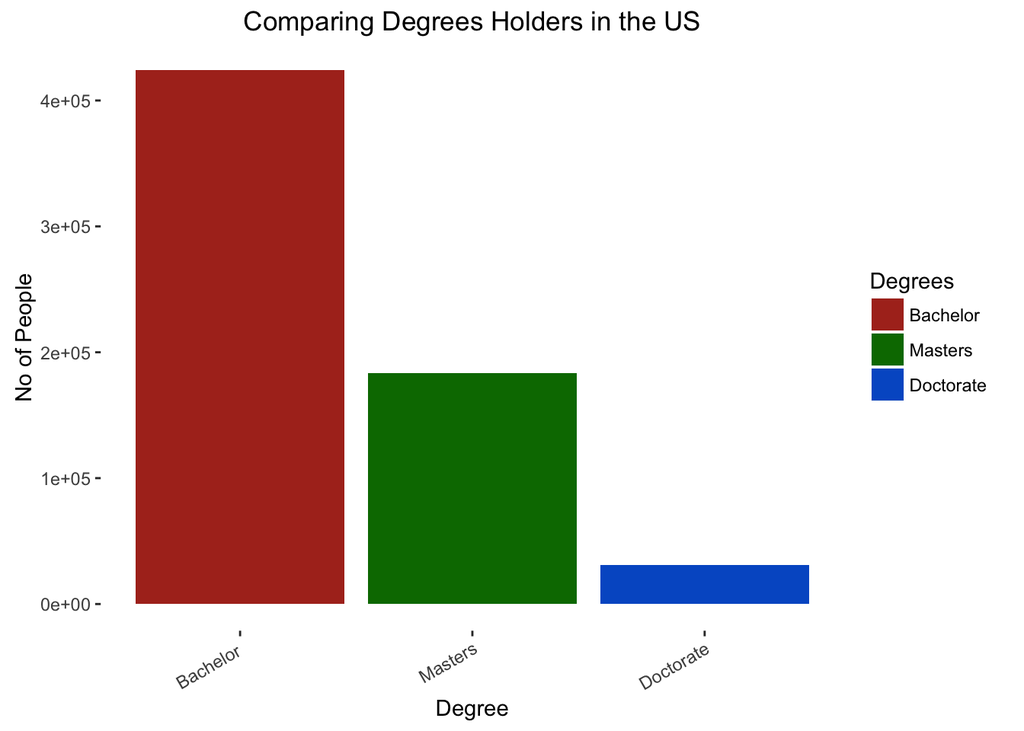

We can see B.Sc holders are much more than the MSc and PhD guys. OK, now we got an idea how many B.Sc, MSc, and PhD guys in the states, so let us now compare their unemployment rates:

```r
#Filter unemployed, group them by degree and calculate rates:
jobLess <- ds %>%
  filter(ESR==3)%>% #3 indicates  Unemployed
  group_by(SCHL) %>%
  summarise(count=n())%>%
  mutate(Percet = count/degreeHolders$count*100)
```

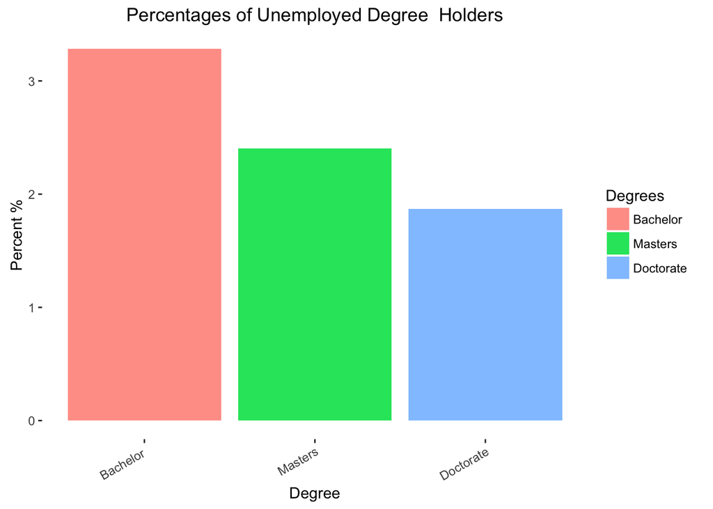

It is clear that PhD guys have the lowest unemployment rate, and it is unlikely that you will be jobless if you do a PhD specifically in particular states.

# Which states are these?

To be honest, I did not plan to check on this, but I could not hold back!

I am curious to know which states have the highest unemployment rate for each group of degree levels. To start with, I do state code mapping here, write it into a data frame and then bind it with `jobLessBSc` extracted below

Then find the total number of B.Sc holders in each state, count those who are unemployed, then compute thier precntages in each state, and finally visualize where they live:

```r
stateTotalBSc  <- ds%>%
  filter(SCHL==21)%>%
  group_by(ST)%>%
  summarise(count = n())

#Do the join before percentage computation to make sure you have a count for each state including 0s
jobLessBSc  <- ds%>%
  filter(SCHL==21, ESR==3)%>%
  group_by(ST)%>%
  summarise(count = n())

jobLessBSc <- right_join(jobLessBSc , stateCodes, by.x=c("ST"))
jobLessBSc[is.na(jobLessBSc)] <- 0
jobLessBSc <- mutate(jobLessBSc, value = jobLessBSc$count/stateTotalBSc$count*100)
```

which produces the this:

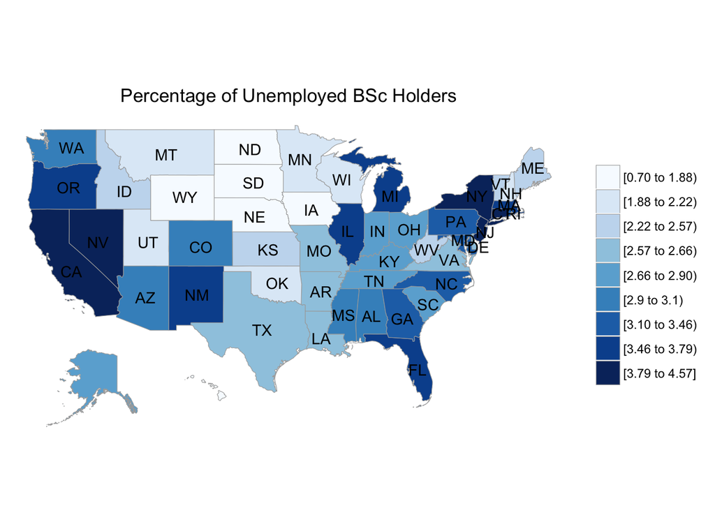

Do the same with MSc:

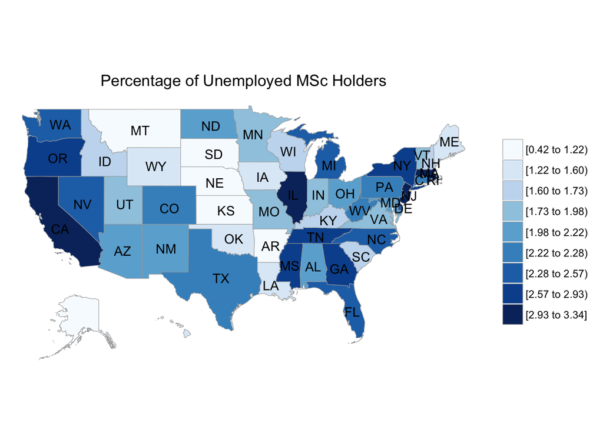

and PhD guys:

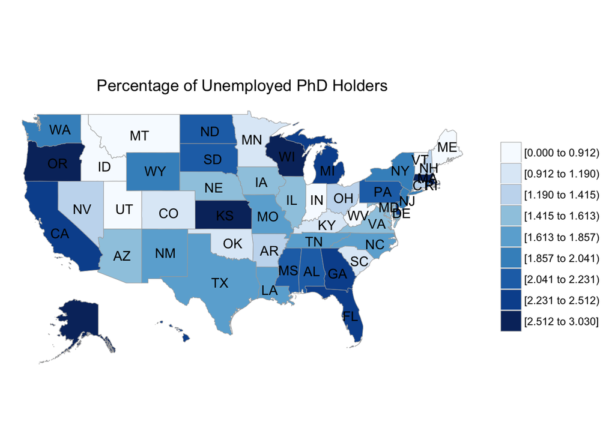